# DATA 606 - Lab 7

### Question 4

Replot the scatterplot, but this time use the function `jitter()` on the $y$- or the $x$-coordinate. (Use `?jitter` to learn more.) What was misleading about the initial scatterplot?

#### Solution

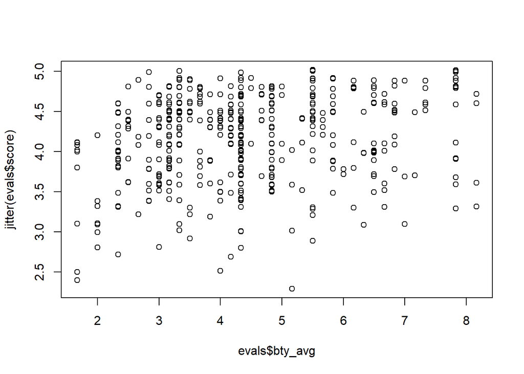

```r
plot(jitter(evals$score)~evals$bty_avg)
```

We can see that there are many points on top of each other, which is why the scatterplot had fewer points.

### Question 5

Let's see if the apparent trend in the plot is something more than natural variation. Fit a linear model called `m_bty` to predict average professor score by average beauty rating and add the line to your plot using `abline(m_bty)`. Write out the equation for the linear model and interpret the slope. Is average beauty score a statistically significant predictor? Does it appear to be a practically significant predictor?

#### Solution

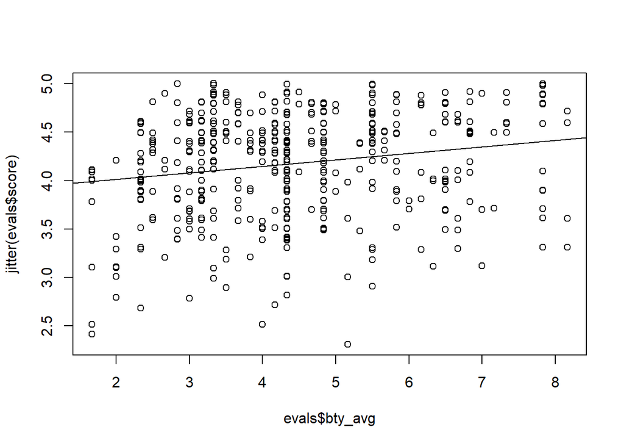

```r
m_bty <- lm(score ~ bty_avg, data = evals)
plot(jitter(evals$score) ~ evals$bty_avg)
abline(m_bty)
```

```r
summary(m_bty)
```

```
##
## Call:
## lm(formula = score ~ bty_avg, data = evals)
##
## Residuals:
##     Min      1Q  Median      3Q     Max
## -1.9246 -0.3690  0.1420  0.3977  0.9309
##
## Coefficients:
##             Estimate Std. Error t value Pr(>|t|)
## (Intercept)  3.88034    0.07614   50.96  < 2e-16 ***
## bty_avg      0.06664    0.01629    4.09 5.08e-05 ***
## ---
## Signif. codes:  0 '***' 0.001 '**' 0.01 '*' 0.05 '.' 0.1 ' ' 1
##
## Residual standard error: 0.5348 on 461 degrees of freedom
## Multiple R-squared:  0.03502,    Adjusted R-squared:  0.03293
## F-statistic: 16.73 on 1 and 461 DF,  p-value: 5.083e-05
```

$\widehat{score} =$ 3.880338 + 0.066637 $\times \text{bty_avg}$

Average beauty score is significant, since its p-value is nearly 0. It's not a practically significant predictor, though, since every additional point in `bty_avg` results in 0.066637 additional points in overall score.

### Question 6

Use residual plots to evaluate whether the conditions of least squares regression are reasonable. Provide plots and comments for each one (see the Simple Regression Lab for a reminder of how to make these).

#### Solution

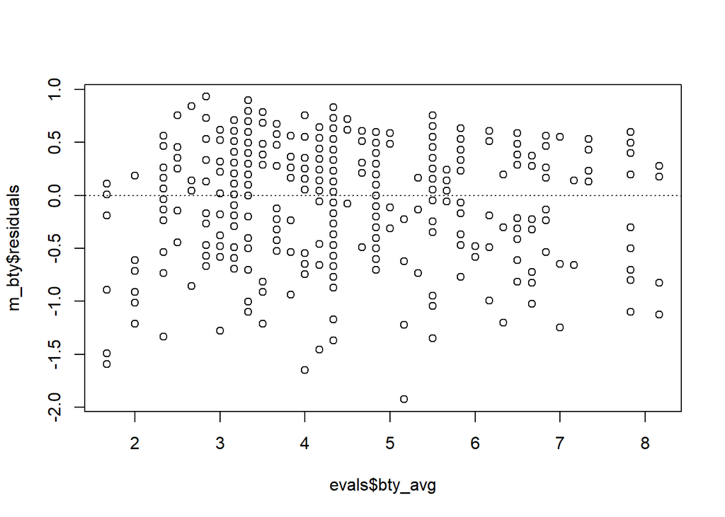

```r
plot(m_bty$residuals ~ evals$bty_avg)
abline(h = 0, lty = 3)
```

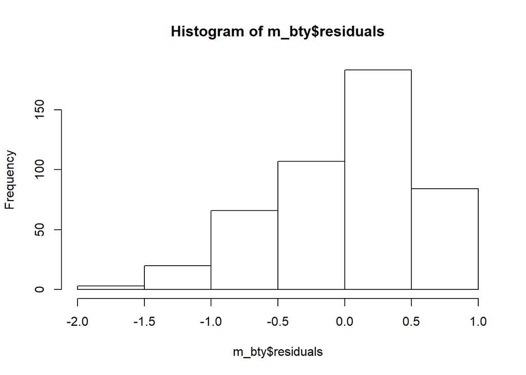

```r
hist(m_bty$residuals)
```

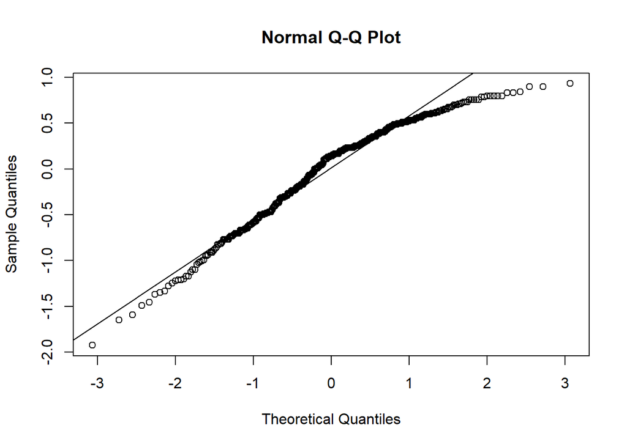

```r
qqnorm(m_bty$residuals)
qqline(m_bty$residuals)
```

The histogram is left-skewed, and the plot does not follow the diagonal line. Since the conditions for least squares regression are not met, we cannot use it in this case.